# Stats 250: Lab 6 Assignment

Elan Grossman

2023-11-02

### Instructions

Complete the lab exercises and Dive Deeper questions below. Lab exercises will be graded out of 2 points each and the Dive Deeper questions will be graded out of 3 points each - all of them will be graded for *correctness*. Upon completion, follow the submission instructions at the bottom of this document. We strongly encourage you to work on this assignment with a partner, but each student must submit their own lab assignment.

### Background

During Lecture Group Work 15 (and posted on Canvas), we asked students to complete a typing test. With this test, students completed a one-minute typing test and were presented with the following results:

- `typingSpeed`: the number of words typed in one minute, including words that had typos (measured in wpm, or words per minute)
- `accuracy`: percentage of words typed correctly
- `netSpeed`: the number of words *correctly* typed in one minute (measured in wpm, or words per minute)

If you’re interested in taking the test yourself, head to the website below and select “1 Minute Test” and “Medium Text”.

[Typing Test Link](https://www.typingtest.com/)

The results for a sample of 164 Stats 250 students are provided in the data set below.

```r
typing <- read.csv("typingSpeedsF23.csv")
```

You can preview the data here.

```r
head(typing)
```

```
##   typingSpeed accuracy netSpeed
## 1          48       95       46
## 2          73       98       72
## 3          62      100       62
## 4          73       98       72
## 5          55      100       55
## 6          65       89       58
```

And be sure to load in the required packages!

```r
library(ggplot2)
```

### Lab Exercises

After reading the background above, complete the following lab exercises. Remember, these exercises are worth 2 points each and are graded for *correctness*.

#### Analysis 1

We would like to estimate the average typing speed of *all* Stats 250 students using the sample of data collected above. Note: this first analysis will involve the `typingSpeed` variable - and our second will involve the net typing speed. Read the background above for the difference between the two variables!

> **1.** Using `ggplot()`, create a QQ plot and histogram for the variable `typingSpeed`. You will comment on these plots in Exercise 2. Be sure that both plots have a title and appropriate axis labels.

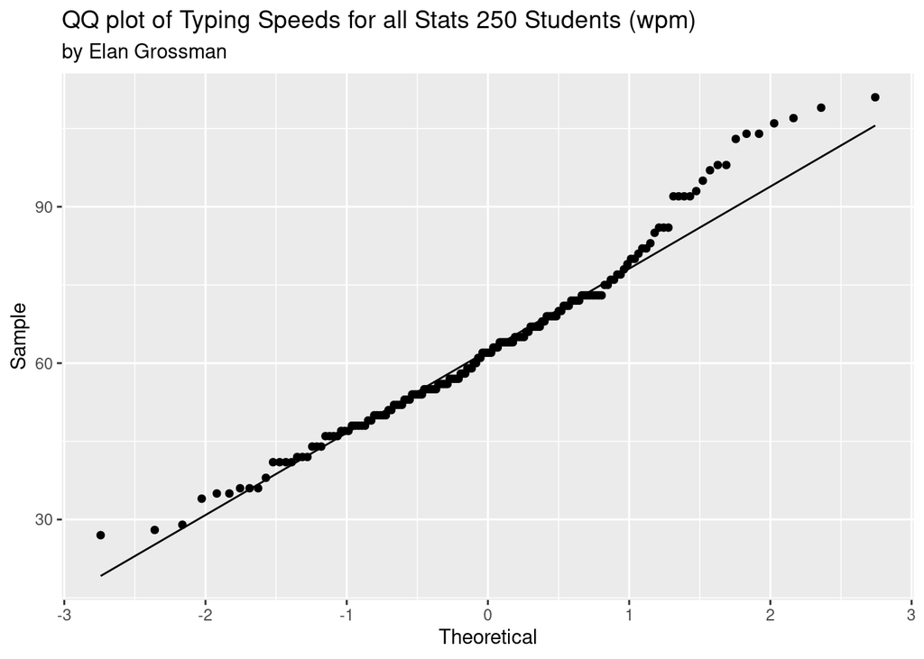

```r
ggplot(typing, aes(sample = typingSpeed)) +
  stat_qq() +
  stat_qq_line()+

  labs(title = "QQ plot of Typing Speeds for all Stats 250 Students (wpm)",
       subtitle = "by Elan Grossman",
       x = "Theoretical",
       y = "Sample")
```

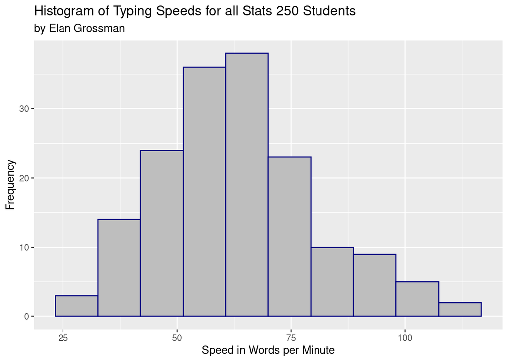

```r
ggplot(data = typing, aes(x = typingSpeed)) +
  geom_histogram(bins = 10,
                 color = "navy",
                 fill = "gray")+
   labs(title = "Histogram of Typing Speeds for all Stats 250 Students",
       subtitle = "by Elan Grossman",
       x = "Speed in Words per Minute",
       y = "Frequency")
```

> **2.** Based on your QQ plot and histogram from Exercise 1, answer the following questions. (1) Observations about the sample: what can we conclude about the sample distribution? (2) Conclusion about the population distribution: based on the sample distribution, what is reasonable to conclude about the population distribution? (3) Conclusion about the sampling distribution: based on the population distribution and sample size, what is reasonable to conclude about the sampling distribution?

*Conclusion about the population distribution:* Since the shape of the sample distribution is reasonably normal, it is reasonable to assume the population distribution the sample was drawn from is normal.

*Conclusion about the sampling distribution:* Since we can assume that the population distribution of responses is normal, we can say that the distribution of all possible sample mean values is normal.

> **3.** Use the `t.test()` function to create a 90% confidence interval for the average typing speed of all Stats 250 students (using the `typingSpeed` variable). Provide an interpretation of your confidence interval within context.

```r
t.test(typing$typingSpeed, confidence_level = 0.90)
```

```
##
##  One Sample t-test
##
## data:  typing$typingSpeed
## t = 46.561, df = 163, p-value < 2.2e-16
## alternative hypothesis: true mean is not equal to 0
## 95 percent confidence interval:
##  60.59680 65.96417
## sample estimates:
## mean of x
##  63.28049
```

*Answer:* We estimate and are 90% confident that the true average typing speed of all Stats 250 students falls within the range of 61.03 to 65.53 words per minute based on our sample data.

> **4.** First, use R to find the t* multiplier used to create the 90% confidence interval in Exercise 3. Then, answer the following question: if a 95% confidence interval was created using the same data, would the resulting interval be narrower, wider, or stay the same width?

```r
qt(p=0.05, df=163, lower.tail = FALSE)
```

```
## [1] 1.654256
```

*Answer:* With 95% confidence the interval is wider since the t multiplier increases as confidence level increases. With 95% confidence, the population mean is between 60.59 and 65.96 cm which is wider than the 90% confidence interval.

#### Analysis 2

The website states that someone with a “fluent” typing proficiency is someone who has a *net* typing speed of 55 words per minute. We would like to assess if the average *net* typing speed of all Stats 250 students is above this value.

> **5.** Use notation to state the null and alternative hypothesis. Then, define your parameter of interest within context. Replace the blank lines below with your answers.

*Answer:* H0: mu = 55 vs Ha: mu > 55

*Answer:* Where mu represents avergae typing speed of all Stats 250 students.

> **6.** Using `ggplot()`, create a histogram for the variable `netSpeed`. Be sure to include a title and appropriate axis labels. Based on this plot, does the sample provide evidence to support the idea that the average net typing speed of all Stats 250 students is above this value? Briefly explain you answer. Note: we are simply asking you to speculate the answer to this question. You will run a hypothesis test in the next exercise to answer this question based on a p-value.

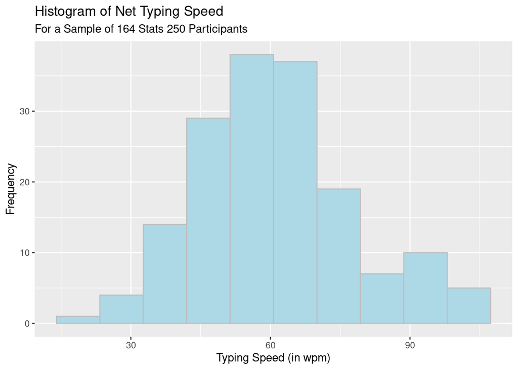

```r
ggplot(data = typing, aes(x = netSpeed)) +

  geom_histogram(bins = 10, color = "grey", fill = "lightblue") +

  labs(title = "Histogram of Net Typing Speed",
       subtitle = "For a Sample of 164 Stats 250 Participants",
       x = "Typing Speed (in wpm)",
       y = "Frequency")
```

> **7.** Use the `t.test()` function and to run the hypothesis test for Analysis 2. Based on the output, evaluate the p-value and provide a conclusion in the context of the problem. Note: you will interpret the p-value in Dive Deeper 1.

```r
t.test(typing$netSpeed, mu = 55, alternative = "greater")
```

```
##
##  One Sample t-test
##
## data:  typing$netSpeed
## t = 4.5518, df = 163, p-value = 5.177e-06
## alternative hypothesis: true mean is greater than 55
## 95 percent confidence interval:
##  58.84661      Inf
## sample estimates:
## mean of x
##  61.04268
```

*Evaluation:* With a p-value of 5.177 e-06, there is very strong evidence against the null hypothesis and in support of the alternative hypothesis.

*Conclusion:* Based on sample data, we have very strong evidence to suggest that the population mean of net typing speed cell greater than 55 words per minute for all stats 250 participants.

### Dive Deeper Questions

After completing the lab exercises above, complete the following Dive Deeper questions. Remember, these questions are worth 3 points each and are graded for correctness.

> **1.** The following interpretation of the p-value (from Exercise 7) is *incomplete*. Finish the statement *within the context* of the hypothesis test. “The probability of observing a t-test statistic of 4.5518 or greater is 0.000005177…”

*Answer:* The probability of observing a t-test statistic of 4.5518 or greater is. 0.000005177, assuming the mean net typing speed for all students is equal to 55 wpm.

> **2.** If we analyze the final variable in the data set, `accuracy`, we find the QQ plot below. We observe that the sample does *not* follow a normal model - because the points pull away from the identity line in a clear pattern. First, why does the QQ plot have a rather long horizontal line of points at 100 with no observations above this value? Hint: think about the variable we are plotting. Second, with a sample size of 164, what will be approximately normal because of the CLT?

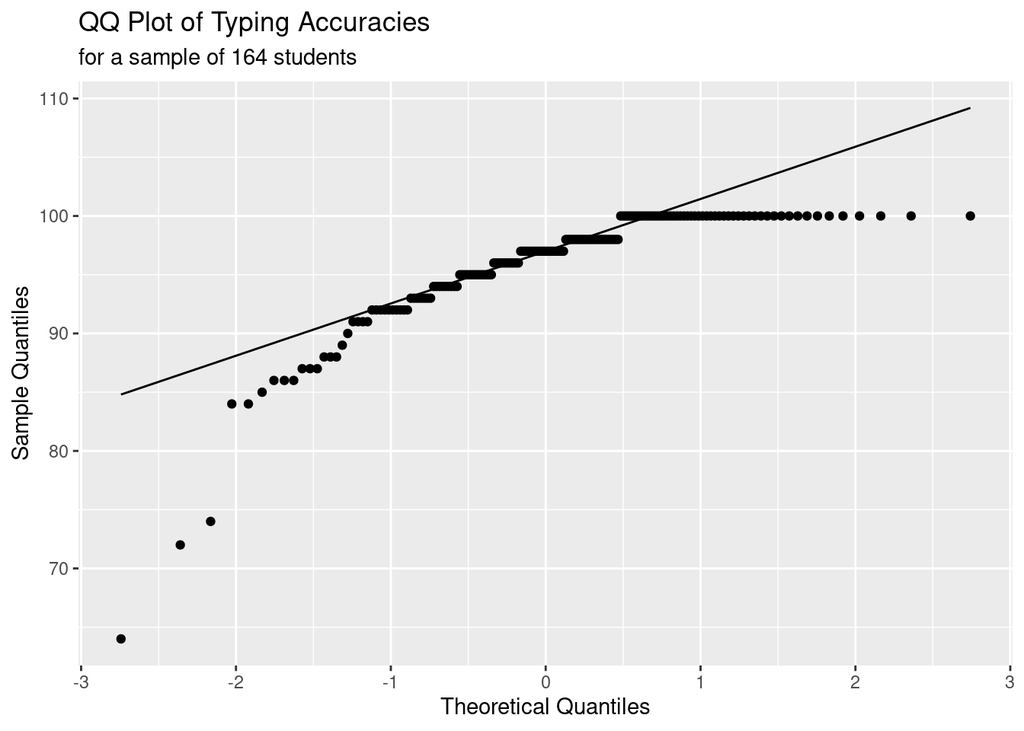

```r
ggplot(data = typing, aes(sample = accuracy)) +

  stat_qq() +
  stat_qq_line() +

  labs(title = "QQ Plot of Typing Accuracies",
       subtitle = "for a sample of 164 students",
       x = "Theoretical Quantiles",
       y = "Sample Quantiles")
```

**Answer 1:** The QQ plot has a long horizontal line of points at 100 with no observations above this value because of the given restrictions on the data set Accuracy. You have have above a 100 percent for words typed correctly. Accuracy measures the correctness of words typed.

**Answer 2:** With a sample size of 164 and the CLT, we can make the assumption that the population of all possible sample mean values for accuracy of stats 250 is approximately normal.

### Submission Instructions

Once you have finished, follow the instructions below to submit your work.

1. At the top of the document, update the `author` field. *Do not change anything else at the top of the document.*
2. Click the Knit button to create an HTML file of your work.
3. In the Files pane (bottom right window), check the box next to `lab06_assignment.html`.
4. In the Files pane, click on the gear icon (More) and select “Export…”
5. Do not change the file name (`lab06_assignment.html`). Click Download and save the file to your computer.
6. On the Stats 250 Canvas site, navigate to the Lab 6 assignment.
7. Upload your saved `lab06_assignment.html` file.
8. Click “Submit Assignment”. Congratulations, you are done with Lab 6!